# Taller R para cientistas sociales

# ¿Con qué trabajamos en R?

- **Scripts**: Un script de R es un archivo de texto que contiene código R.
- **Rmarkdown**: Un documento **Rmd** es un archivo de texto que combina texto con código R. Este formato de documento se utiliza para crear informes, presentaciones y otros tipos de documentos que contienen tanto texto como código. Podés aprender más de rmarkdown [acá](https://rmarkdown.rstudio.com/) y de Quarto (un tipo de documento parecido y más chevere [acá](https://quarto.org/))

➡️ Si apretamos las teclas ALT+CTRL+I podemos introducir un **chunk**. *Es como un mini script,* un espacio para procesar código en R. para ejecutar el código hacemos clic en el **botón verde**

➡️ También podemos correr lineas de código usando CTRL + ENTER

```r
# Esto es un comentario. Para comentar usamos el # o CTRL + ALT + C
```

Uno puede editar la estructura del documento

## Esto es un titulo

### Esto es un titulo mas chiquito

#### Esto es un título mini

Esto es texto normal

*Esto es texto en cursiva*

**Esto es texto en negrita**

# En R todo es un objetos

R es un lenguaje orientado a objetos, lo que significa que todo en R es un objeto. Incluso los números, las funciones y los datos son objetos (“cosas”) en R.

```r
# Creamos un objeto en R

esto_es_un_objeto <- 23
esto_tambien <- "Usamos comillas para el texto para que ningun elemento este suelto"
```

También podemos crear objetos con muchos objetos llamados **vectores**

```r
esto_es_un_vector <- c(1,2,3,4,5,6,7,8,9,10,11,12,13,14,15,16,17)
```

# R es una calculadora

Podemos hacer operaciones matemáticas con R. Y, podemos operar con los objetos

```r
# suma
1 + 3
```

```
## [1] 4
```

```r
# resta
4-2
```

```
## [1] 2
```

```r
# division
25/5
```

```
## [1] 5
```

```r
# multiplicacion
2*2
```

```
## [1] 4
```

```r
# potencia
2^2
```

```
## [1] 4
```

A su vez, podes operar con tus objetos, vectores, dataframes…

```r
# suma con mi objeto

esto_es_un_objeto + 5
```

```
## [1] 28
```

```r
# Puedo crear un objeto con lo nuevo
objeto_nuevo <- esto_es_un_objeto + 5
```

Y usar funciones de R o de librerías para calculos. Las **funciones** como `sum()` o `mean()` son bloques de código reutilizables que realizan tareas específicas. R tiene muchas funciones incorporadas y también podes crear las tuyas propias. *Además hay librerías y paquetes que te permiten ampliar este universo de funciones*

```r
# Tambien operar con mis vectores

mean(esto_es_un_vector)
```

```
## [1] 9
```

```r
sum(esto_es_un_vector)
```

```
## [1] 153
```

Podemos graficar nuestro vector con la función `plot()`

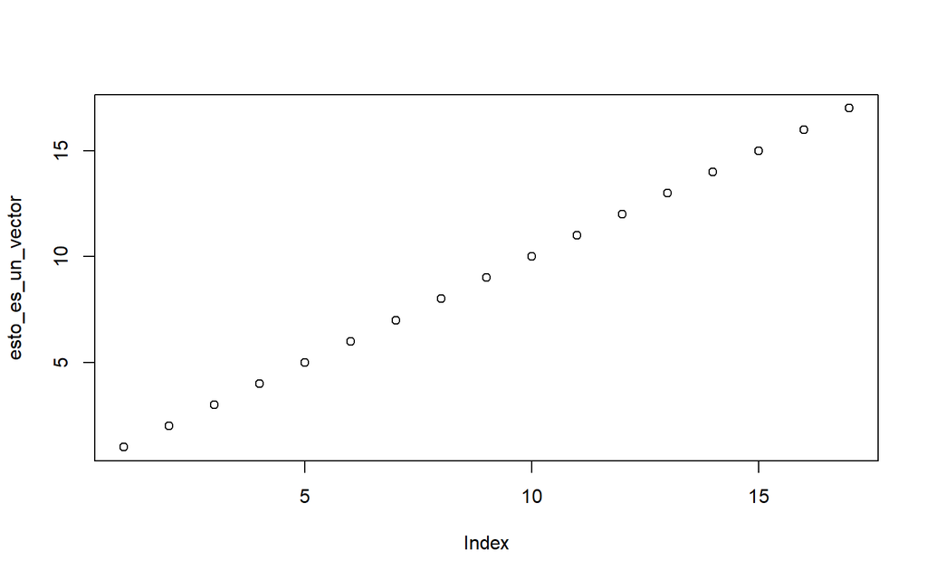

```r
plot(esto_es_un_vector)
```

# Levantar data

📂 En R podemos utilizar archivos csv, txt, excel, sav, entre otros. Incluso podes trabajar con [googlesheets!](https://googlesheets4.tidyverse.org/reference/index.html)

❗Para cada tipo de archivo hay una función diferente. CSV `read.csv()` , archivos SAV `read_spss()` , excel `readxl::read_excel()`

Vamos a trabajar con [*datos abiertos*](https://datosabiertos.desarrollosocial.gob.ar/dataset/potenciar-trabajo) del **Programa Nacional de Inclusión Socioproductiva y Desarrollo Local “Potenciar Trabajo”** que fue creado en el año 2020 bajo la Resolución N° 121. Este programa busca es contribuir al mejoramiento de la empleabilidad y la generación de nuevas propuestas productivas. Para ello, se prevé la participación de las y los titulares del programa en al menos una de las tres alternativas:

- proyectos socio-productivos;
- terminalidad educativa;
- proyectos socio-laborales o socio-comunitarios

```r
#Defino url
# url <- ("https://datosabiertos.desarrollosocial.gob.ar/dataset/d45687c0-f2ba-41d9-9989-0ad9799308ae/resource/c5c925e0-7ce0-41e5-b3ff-8ebb51d4be72/download/potenciar-trabajo-titulares-2022-10-01.csv")
#
# potenciar_trabajo <- read.csv(url)

potenciar_trabajo <- read.csv("data/potenciar-trabajo-titulares-2022-10-01.csv")
```

Para descargarlo a nuestro espacio de trabajo usamos la funcion `write.csv()` para CSV o `write.xlsx` de la librería `openxlsx`

```r
# Guardo el csv
write.csv(potenciar_trabajo, "data/df_potenciar.csv")
```

para leer el archivo desde nuestra compu:

```r
# Leo el df
df <- read.csv("data/df_potenciar.csv")
```

Pueden encontrar más información sobre importacion y exportacion de archivos [aquí](https://r-coder.com/exportar-datos-r/) o [aquí](https://myrbooksp.netlify.app/import.html)

# Analizamos el potenciar trabajo

Primero vamos a ver qué hay en el df del potenciar trabajo

```r
# Primeras 10 observaciones
head(df)
```

```
##   X    periodo    provincia provincia_id           departamento departamento_id
## 1 1 2020-12-01 Buenos Aires            6             25 de Mayo            6854
## 2 2 2020-12-01 Buenos Aires            6             9 de Julio            6588
## 3 3 2020-12-01 Buenos Aires            6          Adolfo Alsina            6007
## 4 4 2020-12-01 Buenos Aires            6 Adolfo Gonzales Chaves            6014
## 5 5 2020-12-01 Buenos Aires            6                Alberti            6021
## 6 6 2020-12-01 Buenos Aires            6        Almirante Brown            6028
##                municipio municipio_id titulares
## 1             25 De Mayo     68540854       379
## 2             9 De Julio     65880588       209
## 3          Adolfo Alsina     60070007       346
## 4 Adolfo Gonzales Chaves     60140014       248
## 5                Alberti     60210021       139
## 6        Almirante Brown     60280028     20469
```

```r
# Ultimas 10 observaciones
tail(df)
```

```
##         X    periodo provincia provincia_id departamento departamento_id
## 4764 4764 2022-12-01   Tucumán           90      Trancas           90112
## 4765 4765 2022-12-01   Tucumán           90      Trancas           90112
## 4766 4766 2022-12-01   Tucumán           90  Yerba Buena           90119
## 4767 4767 2022-12-01   Tucumán           90  Yerba Buena           90119
## 4768 4768 2022-12-01   Tucumán           90  Yerba Buena           90119
## 4769 4769 2022-12-01   Tucumán           90  Yerba Buena           90119
##          municipio municipio_id titulares
## 4764         Tapia    901120104         6
## 4765       Trancas    901120106       536
## 4766 Cevil Redondo    901190019       263
## 4767    San Javier    901190087        29
## 4768 Villa Carmela    901190113        34
## 4769   Yerba Buena    901190112       590
```

Con el simbolo $ puedo elegir las variables de mi tabla y a cada una de ellas puedo aplicarle una función

```r
max(df$titulares) #máximo de titulares
```

```
## [1] 100003
```

```r
min(df$titulares) #mínimo de minimo de titulares
```

```
## [1] 1
```

Para saber más acerca de una función podes pedirle ayuda a R con:

```r
#?max
#help(max)
```

Ver un resumen de los datos

```r
str(df)
```

```
## 'data.frame':    4769 obs. of  9 variables:
##  $ X              : int  1 2 3 4 5 6 7 8 9 10 ...
##  $ periodo        : chr  "2020-12-01" "2020-12-01" "2020-12-01" "2020-12-01" ...
##  $ provincia      : chr  "Buenos Aires" "Buenos Aires" "Buenos Aires" "Buenos Aires" ...
##  $ provincia_id   : int  6 6 6 6 6 6 6 6 6 6 ...
##  $ departamento   : chr  "25 de Mayo" "9 de Julio" "Adolfo Alsina" "Adolfo Gonzales Chaves" ...
##  $ departamento_id: int  6854 6588 6007 6014 6021 6028 6077 6035 6042 6049 ...
##  $ municipio      : chr  "25 De Mayo" "9 De Julio" "Adolfo Alsina" "Adolfo Gonzales Chaves" ...
##  $ municipio_id   : int  68540854 65880588 60070007 60140014 60210021 60280028 60770077 60350035 60420042 60490049 ...
##  $ titulares      : int  379 209 346 248 139 20469 185 12612 250 478 ...
```

```r
summary(df)
```

```
##        X          periodo           provincia          provincia_id
##  Min.   :   1   Length:4769        Length:4769        Min.   : 2.00
##  1st Qu.:1193   Class :character   Class :character   1st Qu.:14.00
##  Median :2385   Mode  :character   Mode  :character   Median :42.00
##  Mean   :2385                                         Mean   :46.31
##  3rd Qu.:3577                                         3rd Qu.:82.00
##  Max.   :4769                                         Max.   :94.00
##  departamento       departamento_id  municipio          municipio_id
##  Length:4769        Min.   : 2001   Length:4769        Min.   :    90014
##  Class :character   1st Qu.:14154   Class :character   1st Qu.:141540062
##  Mode  :character   Median :42035   Mode  :character   Median :420350026
##                     Mean   :46410                      Mean   :463560172
##                     3rd Qu.:82021                      3rd Qu.:820210255
##                     Max.   :94014                      Max.   :940140003
##    titulares
##  Min.   :     1.0
##  1st Qu.:     5.0
##  Median :    28.0
##  Mean   :   759.1
##  3rd Qu.:   165.0
##  Max.   :100003.0
```

# Graficamos

Para graficar usamos ggplot2, es un paquete que se encuentra dentro de Tidyverse.

Tidyverse es un conjunto de paquetes en R diseñados para la ciencia de datos. Estos paquetes comprenden funciones que facilitan el proceso de importación, limpieza, transformación, visualización, modelado y comunicación de datos. Pueden explorarlos mediante la [documentación](https://www.tidyverse.org/packages/)

```r
# install.packages("tidyverse")

library(tidyverse) # Activamos el paquete
```

Para instalar un paquete usamos `install.packages("nombre_del_paquete")` y siempre SIEMPRE que necesitamos usarlo hay que llamarlo en nuestra sesión o documento con `library(nombre_del_paquete)`

Existe una interfaz interactiva que permite dar los primeros pasos en este mundo de la visualización. El paquete `esquisse` te permite hacer un boceto del gráfico y luego copiar el codigo en tu trabajo a través de la función `esquisser`

Vamos a instalar este paquete y vamos a usar la función para hacer un gráfico en el que veamos la cantidad de titulares por provincia.

```r
#instalaremos el paquete esquisse

#install.packages("esquisse") #instalamos el paquete, por unica vez

library(esquisse)
# Otra forma de llamar a las funciones de los paquetes esquisse::esquisser()
#esquisser(df) #corremos la funcion de visualizacion
```